# 04_Biodiversity.Rmd

Morrow Zhang

2026-04-14

```r
start_time <- Sys.time()
set.seed(238428)
pacman::p_load(tidyverse, devtools, patchwork, iNEXT, phyloseq,
               # packages for stats
               ggpubr, rstatix, install = FALSE)
```

```r
load("data/preprocessed_phyloseq.RData")
preprocessed_physeq
```

```
## phyloseq-class experiment-level object
## otu_table()   OTU Table:         [ 446 taxa and 44 samples ]
## sample_data() Sample Data:       [ 44 samples by 37 sample variables ]
## tax_table()   Taxonomy Table:    [ 446 taxa by 9 taxonomic ranks ]
```

```r
min(sample_sums(preprocessed_physeq))
```

```
## [1] 170
```

```r
metadata_df <-
  preprocessed_physeq %>%
  sample_data() %>%
  data.frame()


glimpse(metadata_df)
```

```
## Rows: 44
## Columns: 37
## $ Run                            <chr> "SRR35320041", "SRR35320051", "SRR35320…
## $ Assay.Type                     <chr> "AMPLICON", "AMPLICON", "AMPLICON", "AM…
## $ AvgSpotLen                     <int> 600, 601, 601, 600, 600, 601, 600, 600,…
## $ Bases                          <int> 42870559, 52869386, 48220175, 27932952,…
## $ BioProject                     <chr> "PRJNA1321953", "PRJNA1321953", "PRJNA1…
## $ BioSample                      <chr> "SAMN51231085", "SAMN51231084", "SAMN51…
## $ BioSampleModel                 <chr> "MIMS.me,MIGS/MIMS/MIMARKS.human-gut", …
## $ Bytes                          <int> 27501260, 33837100, 30319981, 17133688,…
## $ Center.Name                    <chr> "JOHNS HOPKINS", "JOHNS HOPKINS", "JOHN…
## $ Collection_Date                <chr> "2020/2022", "2020/2022", "2020/2022", …
## $ collection_method              <chr> "rectal swab", "rectal swab", "rectal s…
## $ Consent                        <chr> "public", "public", "public", "public",…
## $ DATASTORE.filetype             <chr> "fastq,run.zq,sra", "fastq,run.zq,sra",…
```

[output cut: 24 more lines]

```r
iNEXT_input_df <-
  preprocessed_physeq %>%
  otu_table() %>%
  data.frame()

dim(iNEXT_input_df)
```

```
## [1] 446  44
```

```r
iNEXT_input_df[1:5, 1:5]
```

```
##          SRR35320041 SRR35320051 SRR35320062 SRR35320072 SRR35320074
## ASV_0001          30          15           8           0           0
## ASV_0002           0         207          25           0         171
## ASV_0003         484          46          59          58          21
## ASV_0004           0           0           0          45           0
## ASV_0005           0           0           0           0           0
```

```r
iNEXT_data <- iNEXT(
  iNEXT_input_df,
  q = c(0, 1, 2),
  datatype = "abundance"
)


save(iNEXT_data, file = "data/iNEXT_data.RData")
```

```r
str(iNEXT_data)
```

```
## List of 3
##  $ DataInfo:'data.frame':    44 obs. of  14 variables:
##   ..$ Assemblage: chr [1:44] "SRR35320041" "SRR35320051" "SRR35320062" "SRR35320072" ...
##   ..$ n         : num [1:44] 565 357 170 366 240 271 805 357 1830 539 ...
##   ..$ S.obs     : num [1:44] 5 19 15 15 9 11 13 19 9 15 ...
##   ..$ SC        : num [1:44] 1 1 1 0.997 1 ...
##   ..$ f1        : num [1:44] 0 0 0 1 0 0 0 1 0 0 ...
##   ..$ f2        : num [1:44] 1 4 4 1 2 1 2 4 2 4 ...
##   ..$ f3        : num [1:44] 0 4 1 5 1 0 3 3 2 2 ...
##   ..$ f4        : num [1:44] 0 1 4 0 0 1 0 1 0 2 ...
##   ..$ f5        : num [1:44] 1 1 0 0 1 0 1 1 0 0 ...
##   ..$ f6        : num [1:44] 0 2 0 0 0 1 0 0 0 0 ...
##   ..$ f7        : num [1:44] 0 1 2 0 1 1 0 1 2 1 ...
##   ..$ f8        : num [1:44] 0 1 1 0 1 0 0 1 0 0 ...
##   ..$ f9        : num [1:44] 0 0 0 0 0 0 0 0 0 0 ...
##   ..$ f10       : num [1:44] 0 0 0 0 0 0 0 1 0 0 ...
##  $ iNextEst:List of 2
##   ..$ size_based    :'data.frame':   5280 obs. of  10 variables:
##   .. ..$ Assemblage: chr [1:5280] "SRR35320041" "SRR35320041" "SRR35320041" "SRR35320041" ...
##   .. ..$ m         : num [1:5280] 1 32 63 94 126 157 188 219 251 282 ...
##   .. ..$ Method    : chr [1:5280] "Rarefaction" "Rarefaction" "Rarefaction" "Rarefaction" ...
##   .. ..$ Order.q   : num [1:5280] 0 0 0 0 0 0 0 0 0 0 ...
##   .. ..$ qD        : num [1:5280] 1 3.13 3.63 3.9 4.11 ...
##   .. ..$ qD.LCL    : num [1:5280] 1 2.87 3.25 3.45 3.61 ...
##   .. ..$ qD.UCL    : num [1:5280] 1 3.39 4 4.35 4.62 ...
##   .. ..$ SC        : num [1:5280] 0.742 0.975 0.989 0.993 0.994 ...
##   .. ..$ SC.LCL    : num [1:5280] 0.689 0.967 0.986 0.99 0.992 ...
##   .. ..$ SC.UCL    : num [1:5280] 0.795 0.982 0.993 0.995 0.996 ...
##   ..$ coverage_based:'data.frame':   3336 obs. of  8 variables:
##   .. ..$ Assemblage: chr [1:3336] "SRR35320041" "SRR35320041" "SRR35320041" "SRR35320041" ...
##   .. ..$ SC        : num [1:3336] 0.742 0.975 0.989 0.993 0.994 ...
##   .. ..$ m         : num [1:3336] 1 32 63 94 126 157 188 219 251 282 ...
##   .. ..$ Method    : chr [1:3336] "Rarefaction" "Rarefaction" "Rarefaction" "Rarefaction" ...
##   .. ..$ Order.q   : num [1:3336] 0 0 0 0 0 0 0 0 0 0 ...
##   .. ..$ qD        : num [1:3336] 1 3.13 3.63 3.9 4.11 ...
##   .. ..$ qD.LCL    : num [1:3336] 0.92 2.75 3.09 3.28 3.46 ...
##   .. ..$ qD.UCL    : num [1:3336] 1.08 3.51 4.16 4.52 4.77 ...
##  $ AsyEst  :'data.frame':    132 obs. of  7 variables:
##   ..$ Assemblage: chr [1:132] "SRR35320041" "SRR35320041" "SRR35320041" "SRR35320051" ...
##   ..$ Diversity : chr [1:132] "Species richness" "Shannon diversity" "Simpson diversity" "Species richness" ...
##   ..$ Observed  : num [1:132] 5 1.73 1.35 19 5.37 ...
##   ..$ Estimator : num [1:132] 5 1.74 1.35 19 5.51 ...
##   ..$ s.e.      : num [1:132] 0.4038 0.063 0.0375 2.1495 0.4604 ...
##   ..$ LCL       : num [1:132] 5 1.61 1.27 19 4.61 ...
##   ..$ UCL       : num [1:132] 5.79 1.86 1.42 23.21 6.41 ...
##  - attr(*, "class")= chr "iNEXT"
```

```r
typeof(iNEXT_data)
```

```
## [1] "list"
```

```r
color_df <-
  iNEXT_input_df %>%
  colnames() %>%
  data.frame()

head(color_df)
```

```
##             .
## 1 SRR35320041
## 2 SRR35320051
## 3 SRR35320062
## 4 SRR35320072
## 5 SRR35320074
## 6 SRR35320075
```

```r
colnames(color_df)[1] <- "names"

head(color_df)
```

```
##         names
## 1 SRR35320041
## 2 SRR35320051
## 3 SRR35320062
## 4 SRR35320072
## 5 SRR35320074
## 6 SRR35320075
```

```r
iNEXT_color_df <-
  color_df %>%
  # Merge with metadata
  left_join(metadata_df, by = c("names" = "Run")) %>%
  # Add colors for plotting by your real grouping
  mutate(
    AttemptStatus = ifelse(
      grepl("non attempters", source_material_id),
      "Non-attempter",
      "Attempter"
    ),
    attempt_colors = ifelse(
      AttemptStatus == "Non-attempter",
      "blue",
      "red"
    )
  )

head(iNEXT_color_df)
```

```
##         names Assay.Type AvgSpotLen    Bases   BioProject    BioSample
## 1 SRR35320041   AMPLICON        600 42870559 PRJNA1321953 SAMN51231085
## 2 SRR35320051   AMPLICON        601 52869386 PRJNA1321953 SAMN51231084
## 3 SRR35320062   AMPLICON        601 48220175 PRJNA1321953 SAMN51231083
## 4 SRR35320072   AMPLICON        600 27932952 PRJNA1321953 SAMN51231126
## 5 SRR35320074   AMPLICON        600 30216971 PRJNA1321953 SAMN51231124
## 6 SRR35320075   AMPLICON        601 21387436 PRJNA1321953 SAMN51231123
##                        BioSampleModel    Bytes   Center.Name Collection_Date
## 1 MIMS.me,MIGS/MIMS/MIMARKS.human-gut 27501260 JOHNS HOPKINS       2020/2022
## 2 MIMS.me,MIGS/MIMS/MIMARKS.human-gut 33837100 JOHNS HOPKINS       2020/2022
## 3 MIMS.me,MIGS/MIMS/MIMARKS.human-gut 30319981 JOHNS HOPKINS       2020/2022
## 4 MIMS.me,MIGS/MIMS/MIMARKS.human-gut 17133688 JOHNS HOPKINS       2020/2022
## 5 MIMS.me,MIGS/MIMS/MIMARKS.human-gut 18501507 JOHNS HOPKINS       2020/2022
## 6 MIMS.me,MIGS/MIMS/MIMARKS.human-gut 13196458 JOHNS HOPKINS       2020/2022
##   collection_method Consent DATASTORE.filetype DATASTORE.provider
```

[output cut: 55 more lines]

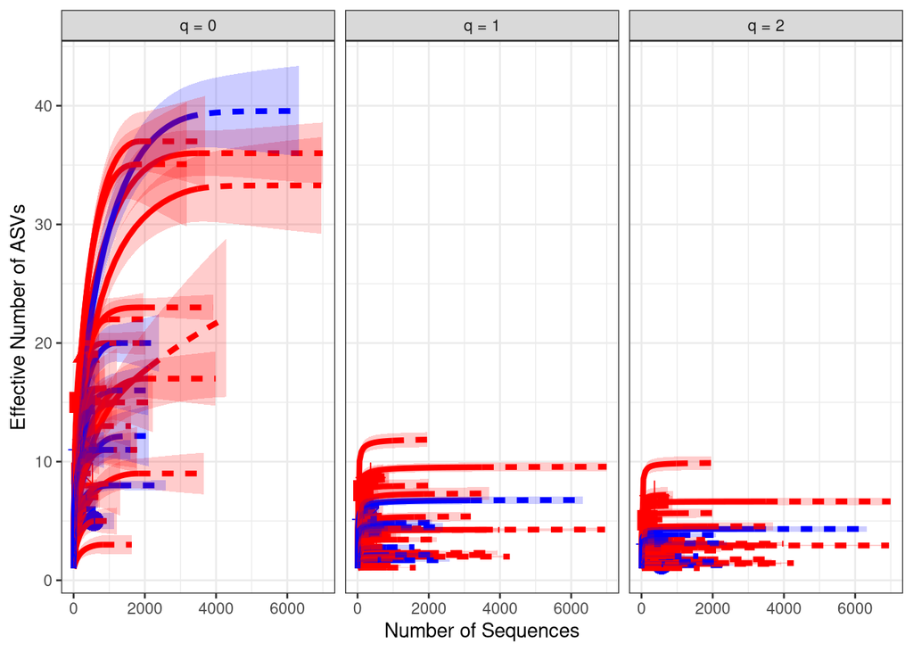

```r
ggiNEXT(iNEXT_data, type = 1, facet.var = "Order.q") +
  scale_color_manual(values = iNEXT_color_df$attempt_colors) +
  scale_fill_manual(values = iNEXT_color_df$attempt_colors) +
  theme_bw() +
  theme(legend.position = "none") +
  labs(y = "Effective Number of ASVs", x = "Number of Sequences")
```

```r
iNEXT_manual_df <-
  iNEXT_data$iNextEst$size_based %>%
  dplyr::rename(names = Assemblage) %>%
  left_join(metadata_df, by = c("names" = "Run")) %>%
  mutate(
    AttemptStatus = ifelse(
      grepl("non attempters", source_material_id),
      "Non-attempter",
      "Attempter"
    )
  )


dim(iNEXT_manual_df)
```

```
## [1] 5280   47
```

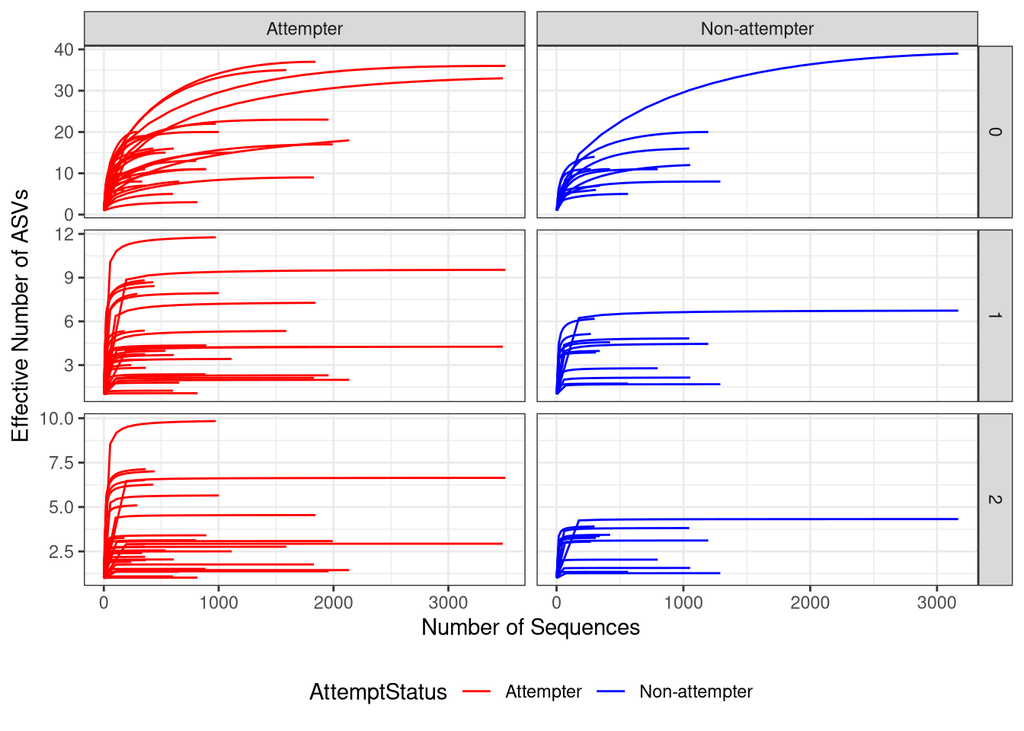

```r
iNEXT_manual_df %>%
  # Filter out rows that are calculated with actual sequences (no extrapolated)
  dplyr::filter(Method == "Rarefaction") %>%
  # Now, let's draw the plot!
  ggplot(aes(x = m, y = qD, color = AttemptStatus, group = names)) +
  geom_line() +
  facet_grid(Order.q ~ AttemptStatus, scales = "free") +
  scale_color_manual(values = c(
    "Attempter" = "red",
    "Non-attempter" = "blue"
  )) +
  theme_bw() +
  labs(y = "Effective Number of ASVs", x = "Number of Sequences") +
  theme(legend.position = "bottom")
```

### Interpretation 1

For the ggiNEXT and manual rarefaction curve plots, there should be enough sequences to analyze for q = 1 and q = 2, but not for q = 0 because many curves in q = 0 are still increasing and have not fully plateaued. Because of that, valid conclusion can be drawn on species richness when q = 1 and q = 2, because the curves stabilize clearly. However, it is probably not valid to draw conclusion when q = 0, because some curves are still increasing.

```r
distinct_metadata_df <- metadata_df
shapiro.test(distinct_metadata_df$AvgSpotLen)
```

```
##
##  Shapiro-Wilk normality test
##
## data:  distinct_metadata_df$AvgSpotLen
## W = 0.66801, p-value = 1.043e-08
```

```r
obs_div_df <-
  iNEXT_manual_df %>%
  dplyr::filter(Method == "Observed")
glimpse(obs_div_df)
```

```
## Rows: 132
## Columns: 47
## $ names                          <chr> "SRR35320041", "SRR35320041", "SRR35320…
## $ m                              <dbl> 565, 565, 565, 357, 357, 357, 170, 170,…
## $ Method                         <chr> "Observed", "Observed", "Observed", "Ob…
## $ Order.q                        <dbl> 0, 1, 2, 0, 1, 2, 0, 1, 2, 0, 1, 2, 0, …
## $ qD                             <dbl> 5.000000, 1.731578, 1.346254, 19.000000…
## $ qD.LCL                         <dbl> 4.356621, 1.572431, 1.247650, 17.257721…
## $ qD.UCL                         <dbl> 5.643379, 1.890725, 1.444857, 20.742279…
## $ SC                             <dbl> 1.0000000, 1.0000000, 1.0000000, 1.0000…
## $ SC.LCL                         <dbl> 0.9993157, 0.9993157, 0.9993157, 0.9927…
## $ SC.UCL                         <dbl> 1, 1, 1, 1, 1, 1, 1, 1, 1, 1, 1, 1, 1, …
## $ Assay.Type                     <chr> "AMPLICON", "AMPLICON", "AMPLICON", "AM…
## $ AvgSpotLen                     <int> 600, 600, 600, 601, 601, 601, 601, 601,…
## $ Bases                          <int> 42870559, 42870559, 42870559, 52869386,…
```

[output cut: 34 more lines]

```r
obs_whole_rich_df <-
  obs_div_df %>%
  dplyr::filter(Order.q == 0)

shapiro.test(obs_whole_rich_df$qD)
```

```
##
##  Shapiro-Wilk normality test
##
## data:  obs_whole_rich_df$qD
## W = 0.87347, p-value = 0.0001833
```

# p-value is less than 0.5 > my data is not normal

```r
kw_attempt_rich <-
  obs_whole_rich_df %>%
  kruskal_test(qD ~ AttemptStatus)

kw_attempt_rich
```

```
## # A tibble: 1 × 6
##   .y.       n statistic    df     p method
## * <chr> <int>     <dbl> <int> <dbl> <chr>
## 1 qD       44      1.54     1 0.214 Kruskal-Wallis
```

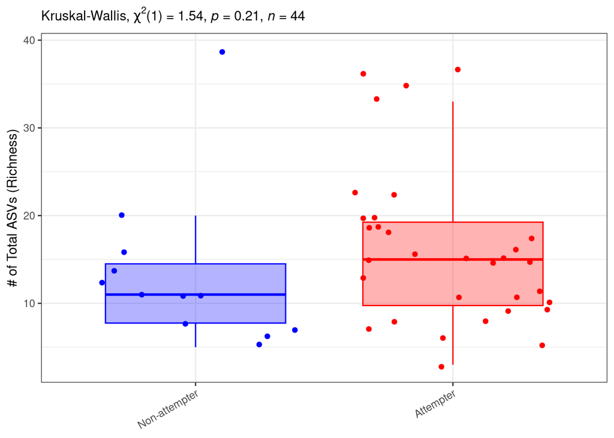

```r
attempt_ggboxplot <-
  ggboxplot(obs_whole_rich_df, x = "AttemptStatus", y = "qD",
            color = "AttemptStatus", fill = "AttemptStatus", alpha = 0.3,
            outlier.shape = NA) +
  # Add points
  geom_jitter(aes(color = AttemptStatus)) +
  scale_color_manual(values = c("Attempter" = "red",
                                "Non-attempter" = "blue")) +
  scale_fill_manual(values = c("Attempter" = "red",
                               "Non-attempter" = "blue")) +
  labs(y = "# of Total ASVs (Richness)") +
  # Now, let's add the KW results
  labs(subtitle = get_test_label(kw_attempt_rich, detailed = TRUE)) +
  theme_bw() +
  theme(legend.position = "none",
        axis.title.x = element_blank(),
        axis.text.x = element_text(angle = 30,
                                   hjust = 1,
                                   vjust = 1))

# Show the plot
attempt_ggboxplot
```

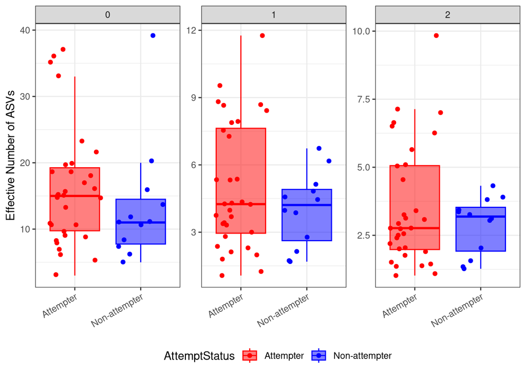

```r
obs_div_df %>%
  ggplot(aes(x = AttemptStatus, y = qD, fill = AttemptStatus,
             color = AttemptStatus)) +
  facet_wrap(.~Order.q, scales = "free_y") +
  geom_jitter() +
  geom_boxplot(alpha = 0.5, outlier.shape = NA) +
  scale_color_manual(values = c("Attempter" = "red",
                                "Non-attempter" = "blue")) +
  scale_fill_manual(values = c("Attempter" = "red",
                               "Non-attempter" = "blue")) +
  labs(y = "Effective Number of ASVs") +
  theme_bw() +
  theme(legend.position = "bottom",
        axis.title.x = element_blank(),
        axis.text.x = element_text(angle = 30,
                                   hjust = 1,
                                   vjust = 1))
```

```r
# I use Wilcox instead of ANOVA, because my data is not normal.

obs_rich_df <-
  obs_div_df %>%
  dplyr::filter(Order.q == 0)


wilcox_attempt_rich <-
  wilcox_test(qD ~ AttemptStatus, data = obs_rich_df, alternative = "greater")


wilcox_attempt_rich
```

```
## # A tibble: 1 × 7
##   .y.   group1    group2           n1    n2 statistic     p
## * <chr> <chr>     <chr>         <int> <int>     <dbl> <dbl>
## 1 qD    Attempter Non-attempter    32    12       239  0.11
```

```r
obs_shannon_df <-
  obs_div_df %>%
  dplyr::filter(Order.q == 1)

wilcox_attempt_shannon <-
  wilcox_test(qD ~ AttemptStatus,
               data = obs_shannon_df, alternative = "greater")

wilcox_attempt_shannon
```

```
## # A tibble: 1 × 7
##   .y.   group1    group2           n1    n2 statistic     p
## * <chr> <chr>     <chr>         <int> <int>     <dbl> <dbl>
## 1 qD    Attempter Non-attempter    32    12       220 0.237
```

```r
obs_simpson_df <-
  obs_div_df %>%
  dplyr::filter(Order.q == 2)

wilcox_attempt_simpson <-
  wilcox_test(qD ~ AttemptStatus,
               data = obs_simpson_df, alternative = "greater")

wilcox_attempt_simpson
```

```
## # A tibble: 1 × 7
##   .y.   group1    group2           n1    n2 statistic     p
## * <chr> <chr>     <chr>         <int> <int>     <dbl> <dbl>
## 1 qD    Attempter Non-attempter    32    12       198 0.443
```

```r
obs_simps_df <-
  obs_div_df %>%
  dplyr::filter(Order.q == 2)
obs_simps_df
```

```
##          names    m   Method Order.q       qD   qD.LCL    qD.UCL        SC
## 1  SRR35320041  565 Observed       2 1.346254 1.247650  1.444857 1.0000000
## 2  SRR35320051  357 Observed       2 2.767442 2.379562  3.155322 1.0000000
## 3  SRR35320062  170 Observed       2 5.047153 3.963242  6.131065 1.0000000
## 4  SRR35320072  366 Observed       2 7.135947 6.476075  7.795819 0.9972826
## 5  SRR35320074  240 Observed       2 1.902371 1.626013  2.178730 1.0000000
## 6  SRR35320075  271 Observed       2 3.045954 2.416283  3.675626 1.0000000
## 7  SRR35320076  805 Observed       2 3.128545 2.936395  3.320696 1.0000000
## 8  SRR35320077  357 Observed       2 6.512135 5.969098  7.055173 0.9972604
## 9  SRR35320079 1830 Observed       2 1.764862 1.710963  1.818761 1.0000000
## 10 SRR35320080  539 Observed       2 2.559228 2.266079  2.852377 1.0000000
## 11 SRR35320082 1292 Observed       2 1.270821 1.221353  1.320289 1.0000000
## 12 SRR35320084  293 Observed       2 5.095803 4.477178  5.714429 1.0000000
## 13 SRR35320085 1003 Observed       2 5.650434 5.254223  6.046646 1.0000000
## 14 SRR35320086  311 Observed       2 3.262421 2.960228  3.564614 1.0000000
```

[output cut: 480 more lines]

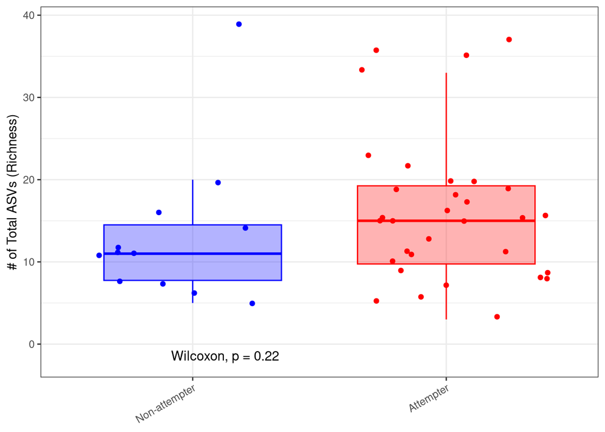

```r
#Rich
rich_ggboxplot <-
  ggboxplot(obs_rich_df, x = "AttemptStatus", y = "qD",
            color = "AttemptStatus", fill = "AttemptStatus", alpha = 0.3,
            outlier.shape = NA) +

  geom_jitter(aes(color = AttemptStatus)) +
  scale_color_manual(values = c("Attempter" = "red",
                                "Non-attempter" = "blue")) +
  scale_fill_manual(values = c("Attempter" = "red",
                               "Non-attempter" = "blue")) +
  labs(y = "# of Total ASVs (Richness)") +
  # Add Wilcoxon
  stat_compare_means(method = "wilcox.test", label.y = min(obs_rich_df$qD) - 5) +
  theme_bw() +
  theme(legend.position = "none",
        axis.title.x = element_blank(),
        axis.text.x = element_text(angle = 30,
                                   hjust = 1,
                                   vjust = 1))

rich_ggboxplot
```

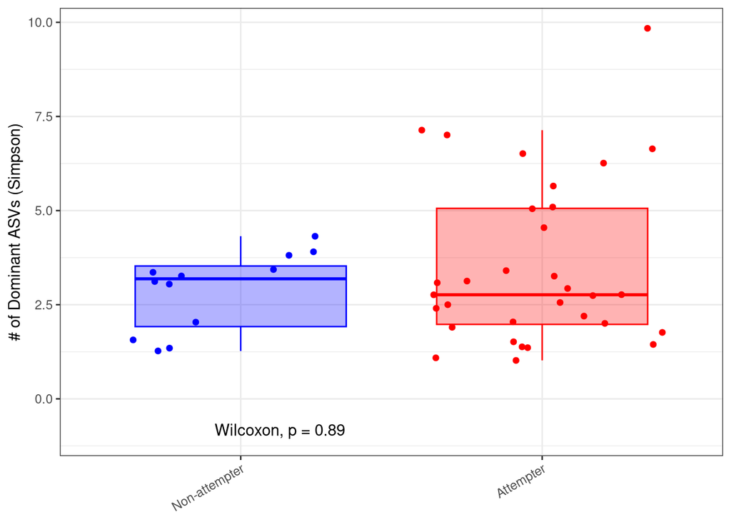

```r
# Simpson by AttemptStatus
simps_ggboxplot <-
  ggboxplot(obs_simps_df, x = "AttemptStatus", y = "qD",
            color = "AttemptStatus", fill = "AttemptStatus", alpha = 0.3,
            outlier.shape = NA) +


  geom_jitter(aes(color = AttemptStatus)) +

  scale_color_manual(values = c("Attempter" = "red",
                                "Non-attempter" = "blue")) +

  scale_fill_manual(values = c("Attempter" = "red",
                               "Non-attempter" = "blue")) +

  labs(y = "# of Dominant ASVs (Simpson)") +

  # Add Wilcoxon
  stat_compare_means(method = "wilcox.test",
                     label.y = min(obs_simps_df$qD) - 2) +

  theme_bw() +
  theme(legend.position = "none",
        axis.title.x = element_blank(),
        axis.text.x = element_text(angle = 30,
                                   hjust = 1,
                                   vjust = 1))

simps_ggboxplot
```

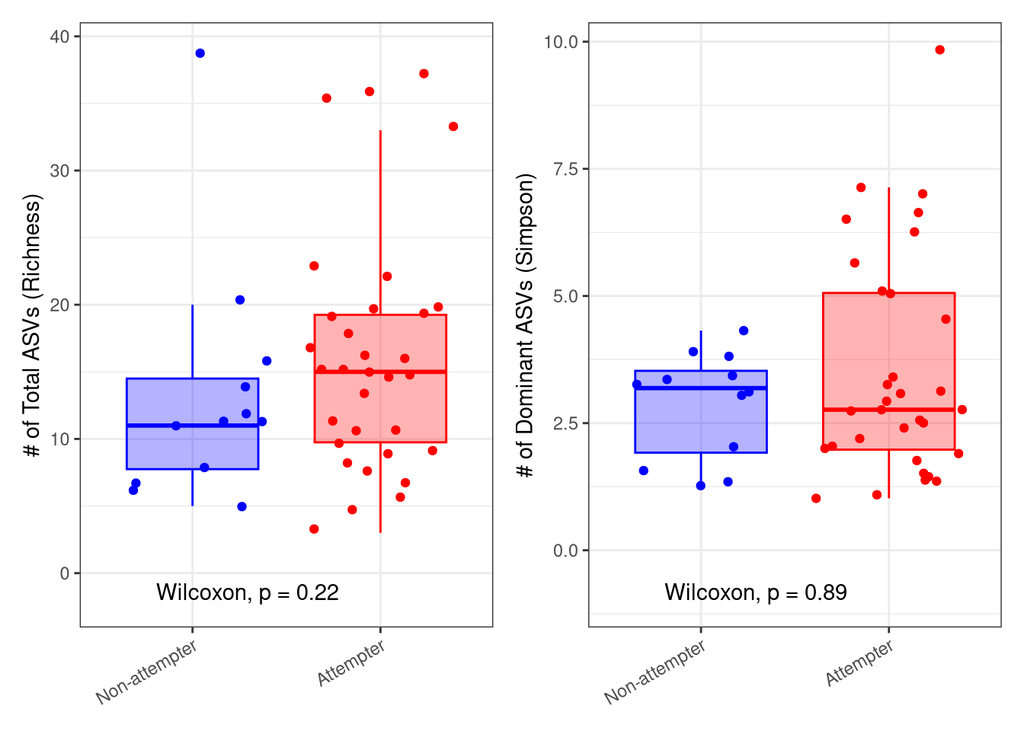

```r
rich_ggboxplot + simps_ggboxplot
```

### Interpretation 2

Wilcoxon rank-sum tests using a one-sided alternative hypothesis showed no significant differences in alpha diversity between suicide attempters and non-attempters across all diversity levels. When q = 0, p value is 0.11. When q = 1, p value is 0.237. When q = 2, p value is 0.443. Overall, these results fail to reject the null hypothesis and indicate that hospitalized MDD patients with recent suicide attempts do not exhibit significantly higher gut microbial alpha diversity compared to those without a history of suicide attempts.

### Interpretation 3

I statistically tested my scientific question using Wilcoxon rank-sum tests to compare alpha diversity between suicide attempters and non-attempters. I used this test because my variable of interest, Attempt Status, is categorical, and my alpha diversity data were not normally distributed, making a non-parametric test more appropriate than ANOVA. I conducted separate one-sided Wilcoxon tests for richness (q = 0), Shannon diversity (q = 1), and Simpson diversity (q = 2), using an alternative hypothesis that alpha diversity would be greater in attempters compared to non-attempters. This allowed me to statistically evaluate whether gut microbial diversity differed between groups across all ASVs, common ASVs, and dominant ASVs.

```r
end_time <- Sys.time()
end_time
```

```
## [1] "2026-04-14 17:41:51 EDT"
```

```r
elapsed_time <- round((end_time - start_time), 3)
elapsed_time
```

```
## Time difference of 1.42 mins
```